# Left Behind

Oct 2025B: Analysis

# Background

This is a preregistered study in the context of local and state-level elections. This is from the preregistration:

## Hypothesis

Feeling left behind is positively associated with voting for political candidates who represent sweeping, as opposed to incremental, change.

## Study design

After pretesting all Gubernatorial and major mayoral races that will be held on Nov. 4th, 2025, we are tracking the following races: NJ Gubernatorial race; NYC Mayoral race; Seattle mayoral race; and Minneapolis mayoral race. These races were selected because one of their top two candidates is clearly seen as representative of sweeping change, while the other is clearly seen as representative of modest/incremental change.

Participants will first indicate the extent to which they feel left behind.

Then, they will indicate their voting intentions on an upcoming state or local election, depending on their place of residence.

Then, they will indicate their views on the two major candidates in that election.

Finally, they will indicate their political ideology and party affiliation, as well as their demographic information.

## Data collection procedure

Data will be collected online via Connect by CloudResearch, using the state (NJ) and zipcode filters (NYC, Seattle, Minneapolis). Participants will be paid at a rate of $12/hour. Participants of previous studies in this project will be excluded from participation.

Note: We are targeting all of NJ, and the following counties: (1) Bronx County, Kings County, New York County, Queens County, Richmond County (NY); (2) King County (WA); and (3) Hennepin County, Carver County, and Anoka County (MN). So, after filtering for state and zipcode on connect, we ask participants for their county to determine which candidates to ask them about. If they are not residents of one of these, that means they erroneously got through the platform filters and will be routed out of the survey.

## Sampling strategy

Target: 300 per race (1200 total).

Stopping rule: Data collection, for each race separately, will start two weeks prior to the election (10/22) and continue until one of the following: (1) the target sample of 300 participants is achieved; (2) one day before the election (11/3).

We also added a Time 2 measure (post-election) that simply asked people who they voted for.

## Analysis plan

Random effects linear model: Continuous left behind measure as the predictor variable; voting intention for the political candidate who supports sweeping change as the outcome variable; election as random effect.

# Eligibility

```r
total_responses <- df_lebe %>%
  nrow()

t2_responses <- df_lebe_elg %>%
  filter(!is.na(vote_t2)) %>%
  nrow()

eligible_n <- df_lebe %>%
  group_by(is_elg) %>%
  summarise(n = n()) %>%
  ungroup() %>%
  filter(is_elg == 1) %>%
  select(n) %>%
  unlist() %>%
  unname()
```

Overall, after routing out participants who do not reside in one of our target counties, we got a total of 495 responses. After filtering completed responses for bots, we got a total of 494 eligible participants. Of those, 329 reported who they ended up voting for in the election.

# Elections

```r
df_lebe_elg %>%
  mutate(t2_response = ifelse(is.na(vote_t2),0,1)) %>%
  group_by(PLACENAME,t2_response) %>%
  summarise(N = n()) %>%
  ungroup() %>%
  pivot_wider(names_from = t2_response,
              values_from = N) %>%
  rename(only_t1 = "0",
         t1_and_t2 = "1") %>%
  kbl() %>%
  kable_styling(bootstrap_options = "hover",
                position = "left") %>%
  scroll_box(width = "100%", height = "400px")
```

| PLACENAME | only_t1 | t1_and_t2 |
| --- | --- | --- |
| Minneapolis | 15 | 24 |
| New Jersey | 91 | 167 |
| New York City | 44 | 116 |
| Seattle | 15 | 22 |

# Demographics (by PLACE)

## Race

```r
df_lebe_elg %>%
  group_by(PLACENAME,race) %>%
  summarise(N = n()) %>%
  group_by(PLACENAME) %>%
  mutate(Perc = round(100*(N/sum(N)),2)) %>%
  ungroup() %>%
  arrange(PLACENAME,desc(N)) %>%
  kbl() %>%
  kable_styling(bootstrap_options = "hover",
                position = "left") %>%
  scroll_box(width = "100%", height = "400px")
```

| PLACENAME | race | N | Perc |
| --- | --- | --- | --- |
| Minneapolis | White | 31 | 79.49 |
| Minneapolis | Black or African American | 4 | 10.26 |
| Minneapolis | Asian | 3 | 7.69 |
| Minneapolis | Other (please specify) | 1 | 2.56 |
| New Jersey | White | 163 | 63.18 |
| New Jersey | Black or African American | 36 | 13.95 |
| New Jersey | Asian | 20 | 7.75 |
| New Jersey | multiracial | 20 | 7.75 |
| New Jersey | Hispanic, Latino, or Spanish origin | 17 | 6.59 |
| New Jersey | Middle Eastern or North African | 1 | 0.39 |
| New Jersey | Other (please specify) | 1 | 0.39 |
| New York City | White | 67 | 41.88 |
| New York City | Asian | 31 | 19.38 |
| New York City | Black or African American | 31 | 19.38 |
| New York City | Hispanic, Latino, or Spanish origin | 17 | 10.62 |
| New York City | multiracial | 10 | 6.25 |
| New York City | Middle Eastern or North African | 2 | 1.25 |
| New York City | Other (please specify) | 1 | 0.62 |
| New York City | NA | 1 | 0.62 |
| Seattle | White | 24 | 64.86 |
| Seattle | Asian | 4 | 10.81 |
| Seattle | multiracial | 4 | 10.81 |
| Seattle | Black or African American | 2 | 5.41 |
| Seattle | Hispanic, Latino, or Spanish origin | 2 | 5.41 |
| Seattle | American Indian or Alaska Native | 1 | 2.70 |

## Gender

```r
df_lebe_elg %>%
  mutate(gender = ifelse(is.na(gender) | gender == "","other",gender)) %>%
  group_by(PLACENAME,gender) %>%
  summarise(N = n()) %>%
  group_by(PLACENAME) %>%
  mutate(Perc = round(100*(N/sum(N)),2)) %>%
  ungroup() %>%
  arrange(PLACENAME,desc(N)) %>%
  kbl() %>%
  kable_styling(bootstrap_options = "hover",
                position = "left") %>%
  scroll_box(width = "100%", height = "400px")
```

| PLACENAME | gender | N | Perc |
| --- | --- | --- | --- |
| Minneapolis | man | 19 | 48.72 |
| Minneapolis | woman | 19 | 48.72 |
| Minneapolis | other | 1 | 2.56 |
| New Jersey | woman | 155 | 60.08 |
| New Jersey | man | 97 | 37.60 |
| New Jersey | other | 6 | 2.33 |
| New York City | woman | 82 | 51.25 |
| New York City | man | 76 | 47.50 |
| New York City | other | 2 | 1.25 |
| Seattle | man | 24 | 64.86 |
| Seattle | woman | 13 | 35.14 |

## Age

```r
df_lebe_elg %>%
  group_by(PLACENAME) %>%
  summarise(age_mean = round(mean(age,na.rm = T),2),
            age_sd = round(sd(age,na.rm = T),2)) %>%
    ungroup() %>%
  kbl() %>%
  kable_styling(bootstrap_options = "hover",
                position = "left") %>%
  scroll_box(width = "100%", height = "400px")
```

| PLACENAME | age_mean | age_sd |
| --- | --- | --- |
| Minneapolis | 35.05 | 11.98 |
| New Jersey | 38.60 | 12.77 |
| New York City | 33.27 | 10.09 |
| Seattle | 40.73 | 14.48 |

## Education

```r
df_lebe_elg %>%
  group_by(PLACENAME,edu) %>%
  summarise(N = n()) %>%
  group_by(PLACENAME) %>%
  mutate(Perc = round(100*(N/sum(N)),2)) %>%
  ungroup() %>%
  kbl() %>%
  kable_styling(bootstrap_options = "hover",
                position = "left") %>%
  scroll_box(width = "100%", height = "400px")
```

| PLACENAME | edu | N | Perc |
| --- | --- | --- | --- |
| Minneapolis | GED | 6 | 15.38 |
| Minneapolis | 2yearColl | 8 | 20.51 |
| Minneapolis | 4yearColl | 19 | 48.72 |
| Minneapolis | MA | 5 | 12.82 |
| Minneapolis | PHD | 1 | 2.56 |
| New Jersey | noHS | 2 | 0.78 |
| New Jersey | GED | 65 | 25.19 |
| New Jersey | 2yearColl | 29 | 11.24 |
| New Jersey | 4yearColl | 107 | 41.47 |
| New Jersey | MA | 42 | 16.28 |
| New Jersey | PHD | 9 | 3.49 |
| New Jersey | NA | 4 | 1.55 |
| New York City | GED | 39 | 24.38 |
| New York City | 2yearColl | 13 | 8.12 |
| New York City | 4yearColl | 76 | 47.50 |
| New York City | MA | 23 | 14.37 |
| New York City | PHD | 9 | 5.62 |
| Seattle | GED | 7 | 18.92 |
| Seattle | 2yearColl | 5 | 13.51 |
| Seattle | 4yearColl | 15 | 40.54 |
| Seattle | MA | 10 | 27.03 |

## Income

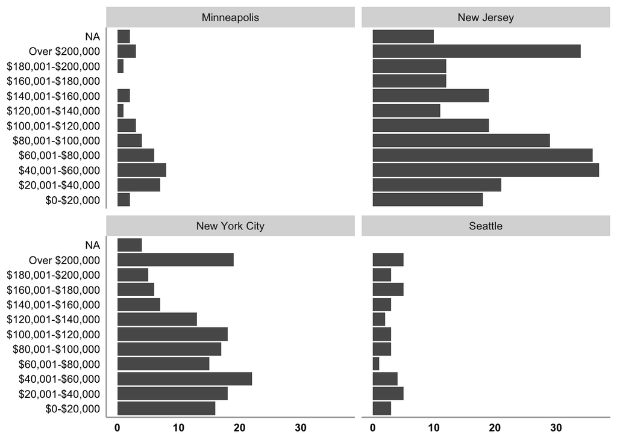

```r
df_lebe_elg %>%
  ggplot(aes(x = income)) +
  geom_bar() +
  theme(panel.grid.major = element_blank(),
        panel.grid.minor = element_blank(),
        panel.background = element_blank(),
        axis.ticks = element_blank(),
        axis.line = element_line(color = "grey66"),
        axis.text.y = element_text(color = "black"),
        axis.text.x = element_text(color = "black",
                                   face = "bold"),
        axis.title.x = element_blank(),
        axis.title.y = element_blank()) +
  coord_flip() +
  facet_wrap(~PLACENAME,nrow = 2)
```

# Political profile

## Ideology

Please indicate your general political ideology (1 = *Extremely Liberal* to 7 = *Extremely Consevative*)

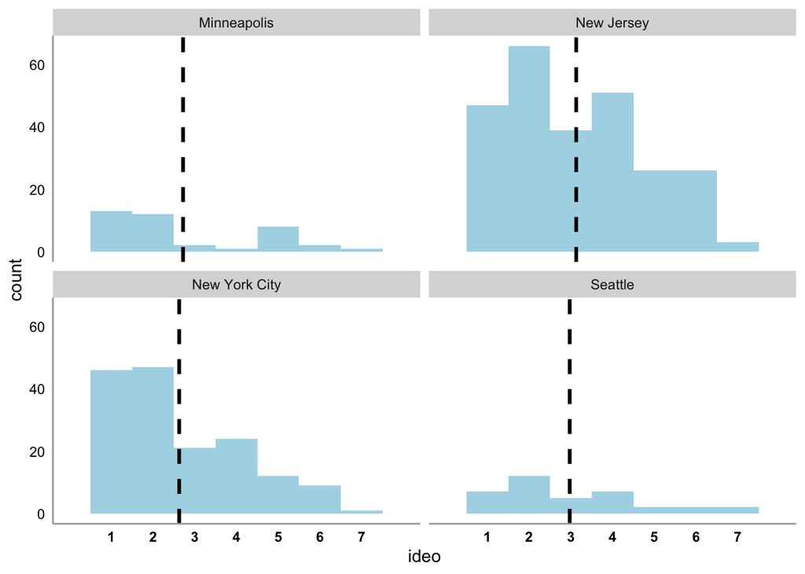

```r
means <- df_lebe_elg %>%
  group_by(PLACENAME) %>%
  summarise(score = mean(ideo,na.rm = T)) %>%
  ungroup()

df_lebe_elg %>%
  ggplot() +
  geom_histogram(aes(x = ideo), fill = "lightblue",color= NA,
                 binwidth = 1) +
  scale_x_continuous(limits = c(0,8),
                     breaks = seq(1,7,1)) +
  geom_vline(data = means,mapping = aes(xintercept = score),
             color = "black",
             linetype = "dashed",
             size = 1.1) +
  theme(panel.grid.major = element_blank(),
        panel.grid.minor = element_blank(),
        panel.background = element_blank(),
        axis.ticks = element_blank(),
        axis.line = element_line(color = "grey66"),
        axis.text.y = element_text(color = "black"),
        axis.text.x = element_text(color = "black",
                                   face = "bold")) +
  facet_wrap(~PLACENAME,nrow = 2)
```

## Party ID

```r
df_lebe_elg %>%
  group_by(PLACENAME,party_gen) %>%
  summarise(N = n()) %>%
  group_by(PLACENAME) %>%
  mutate(Perc = round(100*(N/sum(N)),2)) %>%
  ungroup() %>%
  arrange(PLACENAME,desc(N)) %>%
  kbl() %>%
  kable_styling(bootstrap_options = "hover",
                position = "left") %>%
  scroll_box(width = "100%", height = "400px")
```

| PLACENAME | party_gen | N | Perc |
| --- | --- | --- | --- |
| Minneapolis | Democrat | 23 | 58.97 |
| Minneapolis | Republican | 8 | 20.51 |
| Minneapolis | Independent | 5 | 12.82 |
| Minneapolis | No preference | 2 | 5.13 |
| Minneapolis | Other party | 1 | 2.56 |
| New Jersey | Democrat | 122 | 47.29 |
| New Jersey | Independent | 66 | 25.58 |
| New Jersey | Republican | 48 | 18.60 |
| New Jersey | No preference | 17 | 6.59 |
| New Jersey | Other party | 5 | 1.94 |
| New York City | Democrat | 104 | 65.00 |
| New York City | Independent | 32 | 20.00 |
| New York City | Republican | 15 | 9.38 |
| New York City | No preference | 8 | 5.00 |
| New York City | Other party | 1 | 0.62 |
| Seattle | Democrat | 22 | 59.46 |
| Seattle | Independent | 10 | 27.03 |
| Seattle | Republican | 4 | 10.81 |
| Seattle | No preference | 1 | 2.70 |

# Measures

## Left behind

People in America come from all walks of life. Some feel left behind while others are advancing. We are interested in how you feel and what that means for you.

To what extent do you feel left behind?

Slider: 0 = *Not at All Left Behind*; 100 = *Extremely Left Behind*.

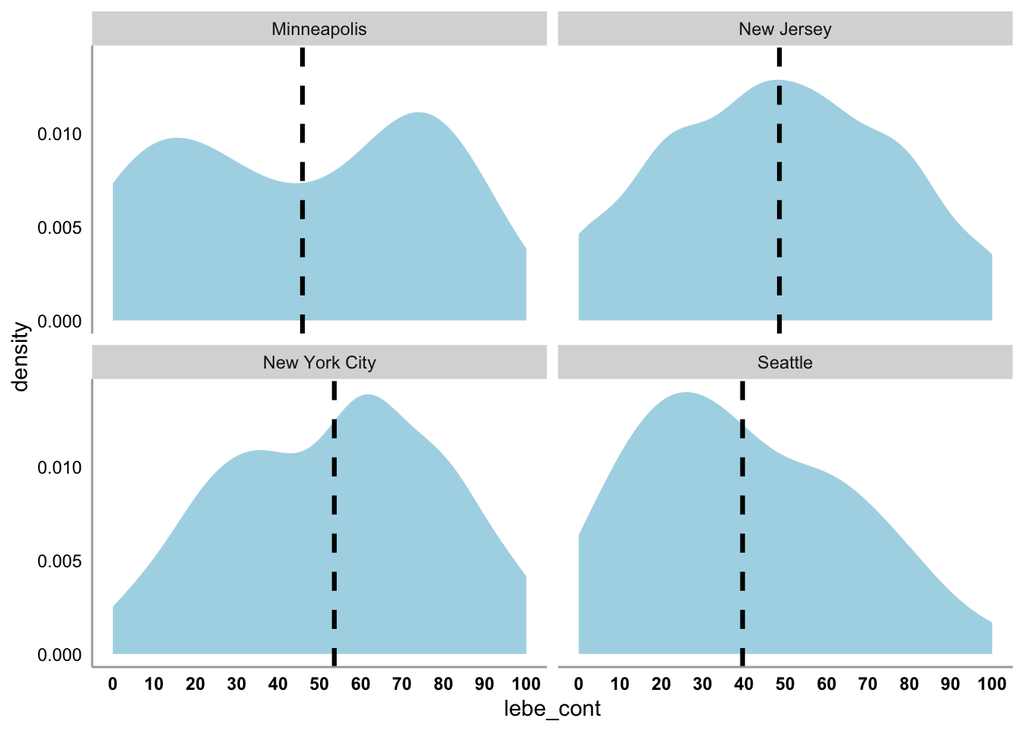

```r
means <- df_lebe_elg %>%
  group_by(PLACENAME) %>%
  summarise(score = mean(lebe_cont,na.rm = T)) %>%
  ungroup()

df_lebe_elg %>%
  ggplot() +
  geom_density(aes(x = lebe_cont), fill = "lightblue",color= NA) +
  scale_x_continuous(limits = c(0,100),
                     breaks = seq(0,100,10)) +
  geom_vline(data = means,mapping = aes(xintercept = score),
             color = "black",
             linetype = "dashed",
             size = 1.1) +
  theme(panel.grid.major = element_blank(),
        panel.grid.minor = element_blank(),
        panel.background = element_blank(),
        axis.ticks = element_blank(),
        axis.line = element_line(color = "grey66"),
        axis.text.y = element_text(color = "black"),
        axis.text.x = element_text(color = "black",
                                   face = "bold")) +
  facet_wrap(~PLACENAME,nrow = 2)
```

## Voter turnout

Do you intend to vote (or have you voted) in the upcoming [MAYORAL/GUBERNATIORAL] election in [CITY/STATE]?

```r
df_lebe_elg %>%
  group_by(PLACENAME,vote_turnout) %>%
  summarise(N = n()) %>%
  group_by(PLACENAME) %>%
  mutate(Perc = round(100*(N/sum(N)),2)) %>%
  ungroup() %>%
  arrange(PLACENAME,vote_turnout) %>%
  kbl() %>%
  kable_styling(bootstrap_options = "hover",
                position = "left") %>%
  scroll_box(width = "100%", height = "400px")
```

| PLACENAME | vote_turnout | N | Perc |
| --- | --- | --- | --- |
| Minneapolis | No | 12 | 30.77 |
| Minneapolis | Not sure | 3 | 7.69 |
| Minneapolis | Yes | 24 | 61.54 |
| New Jersey | No | 30 | 11.63 |
| New Jersey | Not sure | 29 | 11.24 |
| New Jersey | Yes | 199 | 77.13 |
| New York City | No | 17 | 10.62 |
| New York City | Not sure | 15 | 9.38 |
| New York City | Yes | 128 | 80.00 |
| Seattle | No | 6 | 16.22 |
| Seattle | Not sure | 6 | 16.22 |
| Seattle | Yes | 25 | 67.57 |

## Voting intention

Those who said “yes” were asked who they intend to vote for. Those who did not say “yes” were asked who would they vote for *if they had to vote*.

For reference, this is who we pretested:

“sweeping change” candidates: Zohran Mamdani, Jack Ciattarelli, Katie Wilson, Omar Fateh.

“incremental change” candidates: Andrew Cuomo, Mikie Sherill, Bruce Harrell, Jacob Frey

### All participants

```r
df_lebe_elg %>%
  group_by(PLACENAME,vote_who) %>%
  summarise(N = n()) %>%
  group_by(PLACENAME) %>%
  mutate(Perc = round(100*(N/sum(N)),2)) %>%
  ungroup() %>%
  arrange(PLACENAME,desc(N)) %>%
  kbl() %>%
  kable_styling(bootstrap_options = "hover",
                position = "left") %>%
  scroll_box(width = "100%", height = "400px")
```

| PLACENAME | vote_who | N | Perc |
| --- | --- | --- | --- |
| Minneapolis | Jacob Frey | 17 | 43.59 |
| Minneapolis | Omar Fateh | 9 | 23.08 |
| Minneapolis | NA | 8 | 20.51 |
| Minneapolis | DeWayne Davis | 1 | 2.56 |
| Minneapolis | Dewayne Davis | 1 | 2.56 |
| Minneapolis | I wouldn’t vote for either | 1 | 2.56 |
| Minneapolis | Jazz hampton | 1 | 2.56 |
| Minneapolis | Whoever is the Republican | 1 | 2.56 |
| New Jersey | Mikie Sherill | 158 | 61.24 |
| New Jersey | Jack Ciattarelli | 54 | 20.93 |
| New Jersey | NA | 44 | 17.05 |
| New Jersey | ACP Candidate | 1 | 0.39 |
| New Jersey | Definitely leaning towards Jack, but I do have some concerns. I’m really not super fond of either one when it comes down to it. They both worry me in different ways. | 1 | 0.39 |
| New York City | Zohran Mamdani | 110 | 68.75 |
| New York City | NA | 20 | 12.50 |
| New York City | Andrew Cuomo | 19 | 11.88 |
| New York City | Curtis Sliwa | 10 | 6.25 |
| New York City | none | 1 | 0.62 |
| Seattle | Katie Wilson | 18 | 48.65 |
| Seattle | Bruce Harrell | 10 | 27.03 |
| Seattle | NA | 7 | 18.92 |
| Seattle | I would not vote. | 1 | 2.70 |
| Seattle | Jason Rantz | 1 | 2.70 |

For the primary DV, I coded “sweeping change” candidates as 1, “incremental change” candidates as 0, and everyone else as NA. The reason I did this is because we only have pretested data on these eight candidates. Participants may have indicated they want to vote for someone else, and that someone may or may not be seen as sweeping, so I don’t know how to code them. Let’s see (took out NA’s):

```r
df_lebe_elg %>%
  filter(!is.na(vote_sweep)) %>%
  group_by(PLACENAME,vote_sweep) %>%
  summarise(N = n()) %>%
  group_by(PLACENAME) %>%
  mutate(Perc = round(100*(N/sum(N)),2)) %>%
  ungroup() %>%
  arrange(PLACENAME,desc(vote_sweep)) %>%
  kbl() %>%
  kable_styling(bootstrap_options = "hover",
                position = "left") %>%
  scroll_box(width = "100%", height = "400px")
```

| PLACENAME | vote_sweep | N | Perc |
| --- | --- | --- | --- |
| Minneapolis | 1 | 9 | 34.62 |
| Minneapolis | 0 | 17 | 65.38 |
| New Jersey | 1 | 54 | 25.47 |
| New Jersey | 0 | 158 | 74.53 |
| New York City | 1 | 110 | 85.27 |
| New York City | 0 | 19 | 14.73 |
| Seattle | 1 | 18 | 64.29 |
| Seattle | 0 | 10 | 35.71 |

I also, for robustness, have a variable that’s coded as sweeping change = 1, everyone else = 0

```r
df_lebe_elg %>%
  group_by(PLACENAME,vote_sweep_all) %>%
  summarise(N = n()) %>%
  group_by(PLACENAME) %>%
  mutate(Perc = round(100*(N/sum(N)),2)) %>%
  ungroup() %>%
  arrange(PLACENAME,desc(vote_sweep_all)) %>%
  kbl() %>%
  kable_styling(bootstrap_options = "hover",
                position = "left") %>%
  scroll_box(width = "100%", height = "400px")
```

| PLACENAME | vote_sweep_all | N | Perc |
| --- | --- | --- | --- |
| Minneapolis | 1 | 9 | 23.08 |
| Minneapolis | 0 | 30 | 76.92 |
| New Jersey | 1 | 54 | 20.93 |
| New Jersey | 0 | 204 | 79.07 |
| New York City | 1 | 110 | 68.75 |
| New York City | 0 | 50 | 31.25 |
| Seattle | 1 | 18 | 48.65 |
| Seattle | 0 | 19 | 51.35 |

And, the other way around as well: incremental change = 1, everyone else = 0

```r
df_lebe_elg %>%
  group_by(PLACENAME,vote_inc_all) %>%
  summarise(N = n()) %>%
  group_by(PLACENAME) %>%
  mutate(Perc = round(100*(N/sum(N)),2)) %>%
  ungroup() %>%
  arrange(PLACENAME,desc(vote_inc_all)) %>%
  kbl() %>%
  kable_styling(bootstrap_options = "hover",
                position = "left") %>%
  scroll_box(width = "100%", height = "400px")
```

| PLACENAME | vote_inc_all | N | Perc |
| --- | --- | --- | --- |
| Minneapolis | 1 | 17 | 43.59 |
| Minneapolis | 0 | 22 | 56.41 |
| New Jersey | 1 | 158 | 61.24 |
| New Jersey | 0 | 100 | 38.76 |
| New York City | 1 | 19 | 11.88 |
| New York City | 0 | 141 | 88.12 |
| Seattle | 1 | 10 | 27.03 |
| Seattle | 0 | 27 | 72.97 |

### Only those who intend to vote

```r
df_lebe_elg %>%
  filter(vote_turnout == "Yes") %>%
  group_by(PLACENAME,vote_who) %>%
  summarise(N = n()) %>%
  group_by(PLACENAME) %>%
  mutate(Perc = round(100*(N/sum(N)),2)) %>%
  ungroup() %>%
  arrange(PLACENAME,desc(N)) %>%
  kbl() %>%
  kable_styling(bootstrap_options = "hover",
                position = "left") %>%
  scroll_box(width = "100%", height = "400px")
```

| PLACENAME | vote_who | N | Perc |
| --- | --- | --- | --- |
| Minneapolis | Jacob Frey | 8 | 33.33 |
| Minneapolis | Omar Fateh | 7 | 29.17 |
| Minneapolis | NA | 5 | 20.83 |
| Minneapolis | DeWayne Davis | 1 | 4.17 |
| Minneapolis | Dewayne Davis | 1 | 4.17 |
| Minneapolis | Jazz hampton | 1 | 4.17 |
| Minneapolis | Whoever is the Republican | 1 | 4.17 |
| New Jersey | Mikie Sherill | 139 | 69.85 |
| New Jersey | Jack Ciattarelli | 44 | 22.11 |
| New Jersey | NA | 14 | 7.04 |
| New Jersey | ACP Candidate | 1 | 0.50 |
| New Jersey | Definitely leaning towards Jack, but I do have some concerns. I’m really not super fond of either one when it comes down to it. They both worry me in different ways. | 1 | 0.50 |
| New York City | Zohran Mamdani | 98 | 76.56 |
| New York City | Andrew Cuomo | 15 | 11.72 |
| New York City | NA | 10 | 7.81 |
| New York City | Curtis Sliwa | 5 | 3.91 |
| Seattle | Katie Wilson | 15 | 60.00 |
| Seattle | Bruce Harrell | 9 | 36.00 |
| Seattle | Jason Rantz | 1 | 4.00 |

For the primary DV, I coded “sweeping change” candidates as 1, “incremental change” candidates as 0, and everyone else as NA. The reason I did this is because we only have pretested data on these eight candidates. Participants may have indicated they want to vote for someone else, and that someone may or may not be seen as sweeping, so I don’t know how to code them. Let’s see (took out NA’s):

```r
df_lebe_elg %>%
  filter(vote_turnout == "Yes") %>%
  filter(!is.na(vote_sweep)) %>%
  group_by(PLACENAME,vote_sweep) %>%
  summarise(N = n()) %>%
  group_by(PLACENAME) %>%
  mutate(Perc = round(100*(N/sum(N)),2)) %>%
  ungroup() %>%
  arrange(PLACENAME,desc(vote_sweep)) %>%
  kbl() %>%
  kable_styling(bootstrap_options = "hover",
                position = "left") %>%
  scroll_box(width = "100%", height = "400px")
```

| PLACENAME | vote_sweep | N | Perc |
| --- | --- | --- | --- |
| Minneapolis | 1 | 7 | 46.67 |
| Minneapolis | 0 | 8 | 53.33 |
| New Jersey | 1 | 44 | 24.04 |
| New Jersey | 0 | 139 | 75.96 |
| New York City | 1 | 98 | 86.73 |
| New York City | 0 | 15 | 13.27 |
| Seattle | 1 | 15 | 62.50 |
| Seattle | 0 | 9 | 37.50 |

I also, for robustness, have a variable that’s coded as sweeping change = 1, everyone else = 0

```r
df_lebe_elg %>%
  filter(vote_turnout == "Yes") %>%
  group_by(PLACENAME,vote_sweep_all) %>%
  summarise(N = n()) %>%
  group_by(PLACENAME) %>%
  mutate(Perc = round(100*(N/sum(N)),2)) %>%
  ungroup() %>%
  arrange(PLACENAME,desc(vote_sweep_all)) %>%
  kbl() %>%
  kable_styling(bootstrap_options = "hover",
                position = "left") %>%
  scroll_box(width = "100%", height = "400px")
```

| PLACENAME | vote_sweep_all | N | Perc |
| --- | --- | --- | --- |
| Minneapolis | 1 | 7 | 29.17 |
| Minneapolis | 0 | 17 | 70.83 |
| New Jersey | 1 | 44 | 22.11 |
| New Jersey | 0 | 155 | 77.89 |
| New York City | 1 | 98 | 76.56 |
| New York City | 0 | 30 | 23.44 |
| Seattle | 1 | 15 | 60.00 |
| Seattle | 0 | 10 | 40.00 |

And, the other way around as well: incremental change = 1, everyone else = 0

```r
df_lebe_elg %>%
  filter(vote_turnout == "Yes") %>%
  group_by(PLACENAME,vote_inc_all) %>%
  summarise(N = n()) %>%
  group_by(PLACENAME) %>%
  mutate(Perc = round(100*(N/sum(N)),2)) %>%
  ungroup() %>%
  arrange(PLACENAME,desc(vote_inc_all)) %>%
  kbl() %>%
  kable_styling(bootstrap_options = "hover",
                position = "left") %>%
  scroll_box(width = "100%", height = "400px")
```

| PLACENAME | vote_inc_all | N | Perc |
| --- | --- | --- | --- |
| Minneapolis | 1 | 8 | 33.33 |
| Minneapolis | 0 | 16 | 66.67 |
| New Jersey | 1 | 139 | 69.85 |
| New Jersey | 0 | 60 | 30.15 |
| New York City | 1 | 15 | 11.72 |
| New York City | 0 | 113 | 88.28 |
| Seattle | 1 | 9 | 36.00 |
| Seattle | 0 | 16 | 64.00 |

## Voting behavior (T2)

```r
df_lebe_elg %>%
  filter(!is.na(vote_t2)) %>%
  group_by(PLACENAME,vote_t2) %>%
  summarise(N = n()) %>%
  group_by(PLACENAME) %>%
  mutate(Perc = round(100*(N/sum(N)),2)) %>%
  ungroup() %>%
  arrange(PLACENAME,desc(N)) %>%
  kbl() %>%
  kable_styling(bootstrap_options = "hover",
                position = "left") %>%
  scroll_box(width = "100%", height = "400px")
```

| PLACENAME | vote_t2 | N | Perc |
| --- | --- | --- | --- |
| Minneapolis | Jacob Frey | 11 | 45.83 |
| Minneapolis | Omar Fateh | 10 | 41.67 |
| Minneapolis | Davis | 1 | 4.17 |
| Minneapolis | DeWayne Davis | 1 | 4.17 |
| Minneapolis | Jazz Hampton | 1 | 4.17 |
| New Jersey | Mikie Sherill | 126 | 75.45 |
| New Jersey | Jack Ciattarelli | 40 | 23.95 |
| New Jersey | Joanne Kuniansky | 1 | 0.60 |
| New York City | Zohran Mamdani | 80 | 68.97 |
| New York City | Andrew Cuomo | 16 | 13.79 |
| New York City | No Vote | 16 | 13.79 |
| New York City | Curtis Sliwa | 4 | 3.45 |
| Seattle | Katie Wilson | 12 | 54.55 |
| Seattle | Bruce Harrell | 9 | 40.91 |
| Seattle | Jason Rantz | 1 | 4.55 |

## Comparing intentions and behavior

I’ll look only at those who completed the T2 survey.

```r
df_lebe_elg %>%
  filter(!is.na(vote_t2)) %>%
  rename(vote_t1 = vote_who) %>%
  group_by(PLACENAME,vote_t1,vote_t2) %>%
  summarise(N = n()) %>%
  group_by(PLACENAME) %>%
  mutate(Perc = round(100*(N/sum(N)),2)) %>%
  ungroup() %>%
  arrange(PLACENAME,desc(N)) %>%
  kbl() %>%
  kable_styling(bootstrap_options = "hover",
                position = "left") %>%
  scroll_box(width = "100%", height = "400px")
```

| PLACENAME | vote_t1 | vote_t2 | N | Perc |
| --- | --- | --- | --- | --- |
| Minneapolis | Jacob Frey | Jacob Frey | 8 | 33.33 |
| Minneapolis | Omar Fateh | Omar Fateh | 8 | 33.33 |
| Minneapolis | DeWayne Davis | DeWayne Davis | 1 | 4.17 |
| Minneapolis | I wouldn’t vote for either | Jacob Frey | 1 | 4.17 |
| Minneapolis | Jacob Frey | Jazz Hampton | 1 | 4.17 |
| Minneapolis | Jacob Frey | Omar Fateh | 1 | 4.17 |
| Minneapolis | Whoever is the Republican | Jacob Frey | 1 | 4.17 |
| Minneapolis | NA | Davis | 1 | 4.17 |
| Minneapolis | NA | Jacob Frey | 1 | 4.17 |
| Minneapolis | NA | Omar Fateh | 1 | 4.17 |
| New Jersey | Mikie Sherill | Mikie Sherill | 114 | 68.26 |
| New Jersey | Jack Ciattarelli | Jack Ciattarelli | 38 | 22.75 |
| New Jersey | NA | Mikie Sherill | 9 | 5.39 |
| New Jersey | Jack Ciattarelli | Mikie Sherill | 3 | 1.80 |
| New Jersey | NA | Jack Ciattarelli | 2 | 1.20 |
| New Jersey | ACP Candidate | Joanne Kuniansky | 1 | 0.60 |
| New York City | Zohran Mamdani | Zohran Mamdani | 75 | 64.66 |
| New York City | Andrew Cuomo | Andrew Cuomo | 11 | 9.48 |
| New York City | NA | No Vote | 9 | 7.76 |
| New York City | Curtis Sliwa | Andrew Cuomo | 4 | 3.45 |
| New York City | Zohran Mamdani | No Vote | 4 | 3.45 |
| New York City | NA | Zohran Mamdani | 4 | 3.45 |
| New York City | Andrew Cuomo | No Vote | 2 | 1.72 |
| New York City | Curtis Sliwa | Curtis Sliwa | 2 | 1.72 |
| New York City | NA | Curtis Sliwa | 2 | 1.72 |
| New York City | Andrew Cuomo | Zohran Mamdani | 1 | 0.86 |
| New York City | Curtis Sliwa | No Vote | 1 | 0.86 |
| New York City | Zohran Mamdani | Andrew Cuomo | 1 | 0.86 |
| Seattle | Katie Wilson | Katie Wilson | 10 | 45.45 |
| Seattle | Bruce Harrell | Bruce Harrell | 7 | 31.82 |
| Seattle | Bruce Harrell | Katie Wilson | 1 | 4.55 |
| Seattle | Jason Rantz | Jason Rantz | 1 | 4.55 |
| Seattle | Katie Wilson | Bruce Harrell | 1 | 4.55 |
| Seattle | NA | Bruce Harrell | 1 | 4.55 |
| Seattle | NA | Katie Wilson | 1 | 4.55 |

Not a ton of differences. ok.

## Perception of Candidates

### Approach to change

For each candidate, would you describe them as promising a **minor, incremental, and modest** change to how things are done in [PLACENAME] [state/city] government, or a **major, sweeping, and drastic** change in how things are done in [PLACENAME] [state/city] government? (1 = *Incremental* to 7 = *Sweeping*)

```r
df_lebe_elg %>%
  select(PID,PLACENAME,CAND_1:CAND_2,cand1_change,cand2_change) %>%
  pivot_longer(-c(PID,PLACENAME,cand1_change,cand2_change),
               names_to = "names",
               values_to = "candidate") %>%
  mutate(change = ifelse(names == "CAND_1",cand1_change,cand2_change)) %>%
  select(PID,PLACENAME,candidate,change) %>%
  group_by(PLACENAME,candidate) %>%
  summarise(n = n(),
            mean = mean(change,na.rm = T),
            sd = sd(change,na.rm = T)) %>%
  ungroup() %>%
  kbl() %>%
  kable_styling(bootstrap_options = "hover",
                full_width = F,
                position = "left")
```

| PLACENAME | candidate | n | mean | sd |
| --- | --- | --- | --- | --- |
| Minneapolis | Jacob Frey | 39 | 2.641026 | 1.613874 |
| Minneapolis | Omar Fateh | 39 | 5.179487 | 1.553803 |
| New Jersey | Jack Ciattarelli | 258 | 4.604651 | 1.777151 |
| New Jersey | Mikie Sherill | 258 | 3.302326 | 1.518266 |
| New York City | Andrew Cuomo | 160 | 2.493750 | 1.533676 |
| New York City | Zohran Mamdani | 160 | 5.287500 | 1.543448 |
| Seattle | Bruce Harrell | 37 | 2.810811 | 1.411025 |
| Seattle | Katie Wilson | 37 | 4.540540 | 1.168917 |

#### New Jersey

```r
formodel <- df_lebe_elg %>%
  filter(PLACENAME == "New Jersey") %>%
  select(PID,CAND_1:CAND_2,cand1_change,cand2_change) %>%
  pivot_longer(-c(PID,cand1_change,cand2_change),
               names_to = "names",
               values_to = "candidate") %>%
  mutate(change = ifelse(names == "CAND_1",cand1_change,cand2_change)) %>%
  select(PID,candidate,change)

m1 <- rstatix::t_test(change ~ candidate,data = formodel,paired = T,detailed = T)
m2 <- rstatix::cohens_d(formodel,change ~ candidate,paired = T)

d = round(m2$effsize,2)

m1 %>%
  select(statistic,df,p,conf.low,conf.high) %>%
  mutate(d = d) %>%
    kbl() %>%
  kable_styling(bootstrap_options = "hover",
                full_width = F,
                position = "left")
```

| statistic | df | p | conf.low | conf.high | d |
| --- | --- | --- | --- | --- | --- |
| 7.652406 | 257 | 0 | 0.9671907 | 1.63746 | 0.48 |

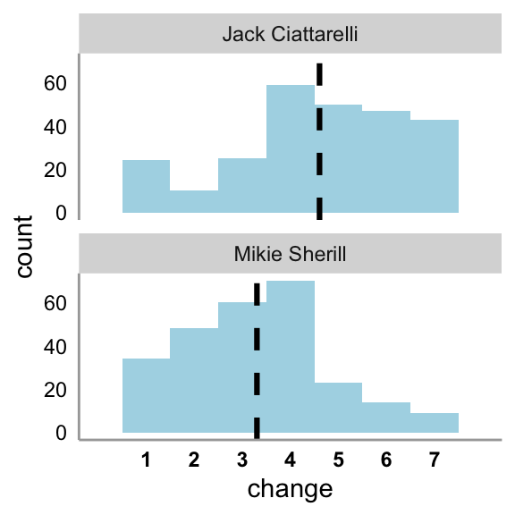

```r
means <- df_lebe_elg %>%
  filter(PLACENAME == "New Jersey") %>%
  select(PID,CAND_1:CAND_2,cand1_change,cand2_change) %>%
  pivot_longer(-c(PID,cand1_change,cand2_change),
               names_to = "names",
               values_to = "candidate") %>%
  mutate(change = ifelse(names == "CAND_1",cand1_change,cand2_change)) %>%
  select(PID,candidate,change) %>%
  group_by(candidate) %>%
  summarise(score = mean(change,na.rm = T)) %>%
  ungroup()

df_lebe_elg %>%
  filter(PLACENAME == "New Jersey") %>%
  select(PID,CAND_1:CAND_2,cand1_change,cand2_change) %>%
  pivot_longer(-c(PID,cand1_change,cand2_change),
               names_to = "names",
               values_to = "candidate") %>%
  mutate(change = ifelse(names == "CAND_1",cand1_change,cand2_change)) %>%
  select(PID,candidate,change) %>%
  ggplot() +
  geom_histogram(aes(x = change),
                 fill = "lightblue",
                 color = NA,
                 binwidth = 1) +
  scale_x_continuous(limits = c(0,8),
                     breaks = seq(1,7,1)) +
  geom_vline(data = means,mapping = aes(xintercept = score),
             color = "black",
             linetype = "dashed",
             size = 1.1) +
  theme(panel.grid.major = element_blank(),
        panel.grid.minor = element_blank(),
        panel.background = element_blank(),
        axis.ticks = element_blank(),
        axis.line = element_line(color = "grey66"),
        axis.text.y = element_text(color = "black"),
        axis.text.x = element_text(color = "black",
                                   face = "bold")) +
  facet_wrap(~candidate,nrow = 2)
```

#### New York City

```r
formodel <- df_lebe_elg %>%
  filter(PLACENAME == "New York City") %>%
  select(PID,CAND_1:CAND_2,cand1_change,cand2_change) %>%
  pivot_longer(-c(PID,cand1_change,cand2_change),
               names_to = "names",
               values_to = "candidate") %>%
  mutate(change = ifelse(names == "CAND_1",cand1_change,cand2_change)) %>%
  select(PID,candidate,change)

m1 <- rstatix::t_test(change ~ candidate,data = formodel,paired = T,detailed = T)
m2 <- rstatix::cohens_d(formodel,change ~ candidate,paired = T)

d = round(m2$effsize,2)

m1 %>%
  select(statistic,df,p,conf.low,conf.high) %>%
  mutate(d = d) %>%
    kbl() %>%
  kable_styling(bootstrap_options = "hover",
                full_width = F,
                position = "left")
```

| statistic | df | p | conf.low | conf.high | d |
| --- | --- | --- | --- | --- | --- |
| -14.45573 | 159 | 0 | -3.175443 | -2.412057 | -1.14 |

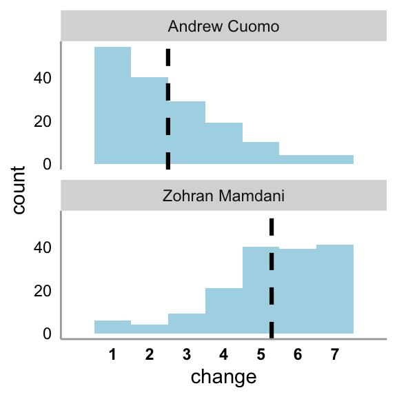

```r
means <- df_lebe_elg %>%
  filter(PLACENAME == "New York City") %>%
  select(PID,CAND_1:CAND_2,cand1_change,cand2_change) %>%
  pivot_longer(-c(PID,cand1_change,cand2_change),
               names_to = "names",
               values_to = "candidate") %>%
  mutate(change = ifelse(names == "CAND_1",cand1_change,cand2_change)) %>%
  select(PID,candidate,change) %>%
  group_by(candidate) %>%
  summarise(score = mean(change,na.rm = T)) %>%
  ungroup()

df_lebe_elg %>%
  filter(PLACENAME == "New York City") %>%
  select(PID,CAND_1:CAND_2,cand1_change,cand2_change) %>%
  pivot_longer(-c(PID,cand1_change,cand2_change),
               names_to = "names",
               values_to = "candidate") %>%
  mutate(change = ifelse(names == "CAND_1",cand1_change,cand2_change)) %>%
  select(PID,candidate,change) %>%
  ggplot() +
  geom_histogram(aes(x = change),
                 fill = "lightblue",
                 color = NA,
                 binwidth = 1) +
  scale_x_continuous(limits = c(0,8),
                     breaks = seq(1,7,1)) +
  geom_vline(data = means,mapping = aes(xintercept = score),
             color = "black",
             linetype = "dashed",
             size = 1.1) +
  theme(panel.grid.major = element_blank(),
        panel.grid.minor = element_blank(),
        panel.background = element_blank(),
        axis.ticks = element_blank(),
        axis.line = element_line(color = "grey66"),
        axis.text.y = element_text(color = "black"),
        axis.text.x = element_text(color = "black",
                                   face = "bold")) +
  facet_wrap(~candidate,nrow = 2)
```

#### Seattle

```r
formodel <- df_lebe_elg %>%
  filter(PLACENAME == "Seattle") %>%
  select(PID,CAND_1:CAND_2,cand1_change,cand2_change) %>%
  pivot_longer(-c(PID,cand1_change,cand2_change),
               names_to = "names",
               values_to = "candidate") %>%
  mutate(change = ifelse(names == "CAND_1",cand1_change,cand2_change)) %>%
  select(PID,candidate,change)

m1 <- rstatix::t_test(change ~ candidate,data = formodel,paired = T,detailed = T)
m2 <- rstatix::cohens_d(formodel,change ~ candidate,paired = T)

d = round(m2$effsize,2)

m1 %>%
  select(statistic,df,p,conf.low,conf.high) %>%
  mutate(d = d) %>%
    kbl() %>%
  kable_styling(bootstrap_options = "hover",
                full_width = F,
                position = "left")
```

| statistic | df | p | conf.low | conf.high | d |
| --- | --- | --- | --- | --- | --- |
| -5.348833 | 36 | 5.2e-06 | -2.385584 | -1.073875 | -0.88 |

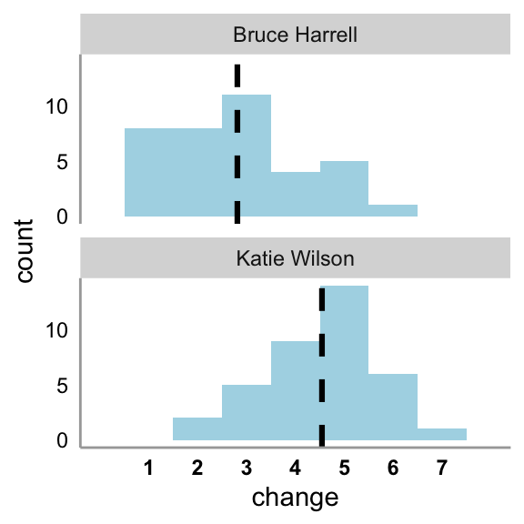

```r
means <- df_lebe_elg %>%
  filter(PLACENAME == "Seattle") %>%
  select(PID,CAND_1:CAND_2,cand1_change,cand2_change) %>%
  pivot_longer(-c(PID,cand1_change,cand2_change),
               names_to = "names",
               values_to = "candidate") %>%
  mutate(change = ifelse(names == "CAND_1",cand1_change,cand2_change)) %>%
  select(PID,candidate,change) %>%
  group_by(candidate) %>%
  summarise(score = mean(change,na.rm = T)) %>%
  ungroup()

df_lebe_elg %>%
  filter(PLACENAME == "Seattle") %>%
  select(PID,CAND_1:CAND_2,cand1_change,cand2_change) %>%
  pivot_longer(-c(PID,cand1_change,cand2_change),
               names_to = "names",
               values_to = "candidate") %>%
  mutate(change = ifelse(names == "CAND_1",cand1_change,cand2_change)) %>%
  select(PID,candidate,change) %>%
  ggplot() +
  geom_histogram(aes(x = change),
                 fill = "lightblue",
                 color = NA,
                 binwidth = 1) +
  scale_x_continuous(limits = c(0,8),
                     breaks = seq(1,7,1)) +
  geom_vline(data = means,mapping = aes(xintercept = score),
             color = "black",
             linetype = "dashed",
             size = 1.1) +
  theme(panel.grid.major = element_blank(),
        panel.grid.minor = element_blank(),
        panel.background = element_blank(),
        axis.ticks = element_blank(),
        axis.line = element_line(color = "grey66"),
        axis.text.y = element_text(color = "black"),
        axis.text.x = element_text(color = "black",
                                   face = "bold")) +
  facet_wrap(~candidate,nrow = 2)
```

#### Minneapolis

```r
formodel <- df_lebe_elg %>%
  filter(PLACENAME == "Minneapolis") %>%
  select(PID,CAND_1:CAND_2,cand1_change,cand2_change) %>%
  pivot_longer(-c(PID,cand1_change,cand2_change),
               names_to = "names",
               values_to = "candidate") %>%
  mutate(change = ifelse(names == "CAND_1",cand1_change,cand2_change)) %>%
  select(PID,candidate,change)

m1 <- rstatix::t_test(change ~ candidate,data = formodel,paired = T,detailed = T)
m2 <- rstatix::cohens_d(formodel,change ~ candidate,paired = T)

d = round(m2$effsize,2)

m1 %>%
  select(statistic,df,p,conf.low,conf.high) %>%
  mutate(d = d) %>%
    kbl() %>%
  kable_styling(bootstrap_options = "hover",
                full_width = F,
                position = "left")
```

| statistic | df | p | conf.low | conf.high | d |
| --- | --- | --- | --- | --- | --- |
| -7.733083 | 38 | 0 | -3.202989 | -1.873934 | -1.24 |

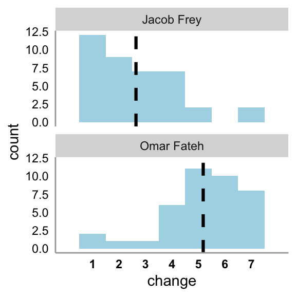

```r
means <- df_lebe_elg %>%
  filter(PLACENAME == "Minneapolis") %>%
  select(PID,CAND_1:CAND_2,cand1_change,cand2_change) %>%
  pivot_longer(-c(PID,cand1_change,cand2_change),
               names_to = "names",
               values_to = "candidate") %>%
  mutate(change = ifelse(names == "CAND_1",cand1_change,cand2_change)) %>%
  select(PID,candidate,change) %>%
  group_by(candidate) %>%
  summarise(score = mean(change,na.rm = T)) %>%
  ungroup()

df_lebe_elg %>%
  filter(PLACENAME == "Minneapolis") %>%
  select(PID,CAND_1:CAND_2,cand1_change,cand2_change) %>%
  pivot_longer(-c(PID,cand1_change,cand2_change),
               names_to = "names",
               values_to = "candidate") %>%
  mutate(change = ifelse(names == "CAND_1",cand1_change,cand2_change)) %>%
  select(PID,candidate,change) %>%
  ggplot() +
  geom_histogram(aes(x = change),
                 fill = "lightblue",
                 color = NA,
                 binwidth = 1) +
  scale_x_continuous(limits = c(0,8),
                     breaks = seq(1,7,1)) +
  geom_vline(data = means,mapping = aes(xintercept = score),
             color = "black",
             linetype = "dashed",
             size = 1.1) +
  theme(panel.grid.major = element_blank(),
        panel.grid.minor = element_blank(),
        panel.background = element_blank(),
        axis.ticks = element_blank(),
        axis.line = element_line(color = "grey66"),
        axis.text.y = element_text(color = "black"),
        axis.text.x = element_text(color = "black",
                                   face = "bold")) +
  facet_wrap(~candidate,nrow = 2)
```

### Direction of change

Mean score of the following items:

**Cultural Issues**

What is their approach to cultural issues? Broadly, they may have a more progressive approach to cultural issues (pro-choice, minority rights, inclusive immigration) or a more conservative approach to cultural issues (pro-life, stronger police, immigration crackdown).

Please indicate the extent to which you believe they are more progressive or conservative on cultural issues. (1 = *Progressive*; 7 = *Conservative*)

**Economic Policy**

What is their approach to economic policy? Broadly, they may be supportive of more redistributive economic policies (high corporate taxes, stronger unions, welfare funding) or more free-market economic policies (low corporate taxes, deregulation, reducing government budget).

Please indicate the extent to which you believe they support redistributive economic policies as opposed to free market economic policies (1 = *Redistributive*; 7 = *Free Market*)

r for cand1 = 0.66

r for cand2 = 0.6

```r
df_lebe_elg %>%
  select(PID,PLACENAME,CAND_1:CAND_2,cand1_rightwing,cand2_rightwing) %>%
  pivot_longer(-c(PID,PLACENAME,cand1_rightwing,cand2_rightwing),
               names_to = "names",
               values_to = "candidate") %>%
  mutate(rightwing = ifelse(names == "CAND_1",cand1_rightwing,cand2_rightwing)) %>%
  select(PID,PLACENAME,candidate,rightwing) %>%
  group_by(PLACENAME,candidate) %>%
  summarise(n = n(),
            mean = mean(rightwing,na.rm = T),
            sd = sd(rightwing,na.rm = T)) %>%
  ungroup() %>%
  kbl() %>%
  kable_styling(bootstrap_options = "hover",
                full_width = F,
                position = "left")
```

| PLACENAME | candidate | n | mean | sd |
| --- | --- | --- | --- | --- |
| Minneapolis | Jacob Frey | 39 | 3.923077 | 1.453392 |
| Minneapolis | Omar Fateh | 39 | 2.448718 | 1.281420 |
| New Jersey | Jack Ciattarelli | 258 | 5.662791 | 1.192817 |
| New Jersey | Mikie Sherill | 258 | 2.763566 | 1.152020 |
| New York City | Andrew Cuomo | 160 | 4.937500 | 1.217986 |
| New York City | Zohran Mamdani | 160 | 2.153125 | 1.108851 |
| Seattle | Bruce Harrell | 37 | 3.918919 | 1.406895 |
| Seattle | Katie Wilson | 37 | 2.527027 | 1.379140 |

#### New Jersey

```r
formodel <- df_lebe_elg %>%
  filter(PLACENAME == "New Jersey") %>%
  select(PID,CAND_1:CAND_2,cand1_rightwing,cand2_rightwing) %>%
  pivot_longer(-c(PID,cand1_rightwing,cand2_rightwing),
               names_to = "names",
               values_to = "candidate") %>%
  mutate(rightwing = ifelse(names == "CAND_1",cand1_rightwing,cand2_rightwing)) %>%
  select(PID,candidate,rightwing)

m1 <- rstatix::t_test(rightwing ~ candidate,data = formodel,paired = T,detailed = T)
m2 <- rstatix::cohens_d(formodel,rightwing ~ candidate,paired = T)

d = round(m2$effsize,2)

m1 %>%
  select(statistic,df,p,conf.low,conf.high) %>%
  mutate(d = d) %>%
    kbl() %>%
  kable_styling(bootstrap_options = "hover",
                full_width = F,
                position = "left")
```

| statistic | df | p | conf.low | conf.high | d |
| --- | --- | --- | --- | --- | --- |
| 22.67084 | 257 | 0 | 2.647392 | 3.151058 | 1.41 |

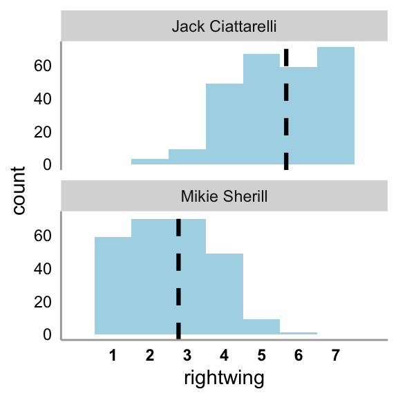

```r
means <- df_lebe_elg %>%
  filter(PLACENAME == "New Jersey") %>%
  select(PID,CAND_1:CAND_2,cand1_rightwing,cand2_rightwing) %>%
  pivot_longer(-c(PID,cand1_rightwing,cand2_rightwing),
               names_to = "names",
               values_to = "candidate") %>%
  mutate(rightwing = ifelse(names == "CAND_1",cand1_rightwing,cand2_rightwing)) %>%
  select(PID,candidate,rightwing) %>%
  group_by(candidate) %>%
  summarise(score = mean(rightwing,na.rm = T)) %>%
  ungroup()

df_lebe_elg %>%
  filter(PLACENAME == "New Jersey") %>%
  select(PID,CAND_1:CAND_2,cand1_rightwing,cand2_rightwing) %>%
  pivot_longer(-c(PID,cand1_rightwing,cand2_rightwing),
               names_to = "names",
               values_to = "candidate") %>%
  mutate(rightwing = ifelse(names == "CAND_1",cand1_rightwing,cand2_rightwing)) %>%
  select(PID,candidate,rightwing) %>%
  ggplot() +
  geom_histogram(aes(x = rightwing),
                 fill = "lightblue",
                 color = NA,
                 binwidth = 1) +
  scale_x_continuous(limits = c(0,8),
                     breaks = seq(1,7,1)) +
  geom_vline(data = means,mapping = aes(xintercept = score),
             color = "black",
             linetype = "dashed",
             size = 1.1) +
  theme(panel.grid.major = element_blank(),
        panel.grid.minor = element_blank(),
        panel.background = element_blank(),
        axis.ticks = element_blank(),
        axis.line = element_line(color = "grey66"),
        axis.text.y = element_text(color = "black"),
        axis.text.x = element_text(color = "black",
                                   face = "bold")) +
  facet_wrap(~candidate,nrow = 2)
```

#### New York City

```r
formodel <- df_lebe_elg %>%
  filter(PLACENAME == "New York City") %>%
  select(PID,CAND_1:CAND_2,cand1_rightwing,cand2_rightwing) %>%
  pivot_longer(-c(PID,cand1_rightwing,cand2_rightwing),
               names_to = "names",
               values_to = "candidate") %>%
  mutate(rightwing = ifelse(names == "CAND_1",cand1_rightwing,cand2_rightwing)) %>%
  select(PID,candidate,rightwing)

m1 <- rstatix::t_test(rightwing ~ candidate,data = formodel,paired = T,detailed = T)
m2 <- rstatix::cohens_d(formodel,rightwing ~ candidate,paired = T)

d = round(m2$effsize,2)

m1 %>%
  select(statistic,df,p,conf.low,conf.high) %>%
  mutate(d = d) %>%
    kbl() %>%
  kable_styling(bootstrap_options = "hover",
                full_width = F,
                position = "left")
```

| statistic | df | p | conf.low | conf.high | d |
| --- | --- | --- | --- | --- | --- |
| 18.87999 | 159 | 0 | 2.493107 | 3.075643 | 1.49 |

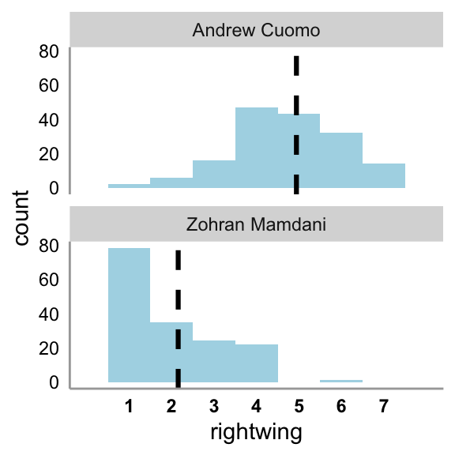

```r
means <- df_lebe_elg %>%
  filter(PLACENAME == "New York City") %>%
  select(PID,CAND_1:CAND_2,cand1_rightwing,cand2_rightwing) %>%
  pivot_longer(-c(PID,cand1_rightwing,cand2_rightwing),
               names_to = "names",
               values_to = "candidate") %>%
  mutate(rightwing = ifelse(names == "CAND_1",cand1_rightwing,cand2_rightwing)) %>%
  select(PID,candidate,rightwing) %>%
  group_by(candidate) %>%
  summarise(score = mean(rightwing,na.rm = T)) %>%
  ungroup()

df_lebe_elg %>%
  filter(PLACENAME == "New York City") %>%
  select(PID,CAND_1:CAND_2,cand1_rightwing,cand2_rightwing) %>%
  pivot_longer(-c(PID,cand1_rightwing,cand2_rightwing),
               names_to = "names",
               values_to = "candidate") %>%
  mutate(rightwing = ifelse(names == "CAND_1",cand1_rightwing,cand2_rightwing)) %>%
  select(PID,candidate,rightwing) %>%
  ggplot() +
  geom_histogram(aes(x = rightwing),
                 fill = "lightblue",
                 color = NA,
                 binwidth = 1) +
  scale_x_continuous(limits = c(0,8),
                     breaks = seq(1,7,1)) +
  geom_vline(data = means,mapping = aes(xintercept = score),
             color = "black",
             linetype = "dashed",
             size = 1.1) +
  theme(panel.grid.major = element_blank(),
        panel.grid.minor = element_blank(),
        panel.background = element_blank(),
        axis.ticks = element_blank(),
        axis.line = element_line(color = "grey66"),
        axis.text.y = element_text(color = "black"),
        axis.text.x = element_text(color = "black",
                                   face = "bold")) +
  facet_wrap(~candidate,nrow = 2)
```

#### Seattle

```r
formodel <- df_lebe_elg %>%
  filter(PLACENAME == "Seattle") %>%
  select(PID,CAND_1:CAND_2,cand1_rightwing,cand2_rightwing) %>%
  pivot_longer(-c(PID,cand1_rightwing,cand2_rightwing),
               names_to = "names",
               values_to = "candidate") %>%
  mutate(rightwing = ifelse(names == "CAND_1",cand1_rightwing,cand2_rightwing)) %>%
  select(PID,candidate,rightwing)

m1 <- rstatix::t_test(rightwing ~ candidate,data = formodel,paired = T,detailed = T)
m2 <- rstatix::cohens_d(formodel,rightwing ~ candidate,paired = T)

d = round(m2$effsize,2)

m1 %>%
  select(statistic,df,p,conf.low,conf.high) %>%
  mutate(d = d) %>%
    kbl() %>%
  kable_styling(bootstrap_options = "hover",
                full_width = F,
                position = "left")
```

| statistic | df | p | conf.low | conf.high | d |
| --- | --- | --- | --- | --- | --- |
| 4.798634 | 36 | 2.78e-05 | 0.8036229 | 1.980161 | 0.79 |

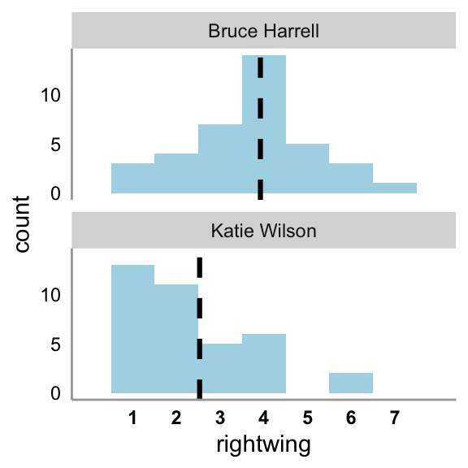

```r
means <- df_lebe_elg %>%
  filter(PLACENAME == "Seattle") %>%
  select(PID,CAND_1:CAND_2,cand1_rightwing,cand2_rightwing) %>%
  pivot_longer(-c(PID,cand1_rightwing,cand2_rightwing),
               names_to = "names",
               values_to = "candidate") %>%
  mutate(rightwing = ifelse(names == "CAND_1",cand1_rightwing,cand2_rightwing)) %>%
  select(PID,candidate,rightwing) %>%
  group_by(candidate) %>%
  summarise(score = mean(rightwing,na.rm = T)) %>%
  ungroup()

df_lebe_elg %>%
  filter(PLACENAME == "Seattle") %>%
  select(PID,CAND_1:CAND_2,cand1_rightwing,cand2_rightwing) %>%
  pivot_longer(-c(PID,cand1_rightwing,cand2_rightwing),
               names_to = "names",
               values_to = "candidate") %>%
  mutate(rightwing = ifelse(names == "CAND_1",cand1_rightwing,cand2_rightwing)) %>%
  select(PID,candidate,rightwing) %>%
  ggplot() +
  geom_histogram(aes(x = rightwing),
                 fill = "lightblue",
                 color = NA,
                 binwidth = 1) +
  scale_x_continuous(limits = c(0,8),
                     breaks = seq(1,7,1)) +
  geom_vline(data = means,mapping = aes(xintercept = score),
             color = "black",
             linetype = "dashed",
             size = 1.1) +
  theme(panel.grid.major = element_blank(),
        panel.grid.minor = element_blank(),
        panel.background = element_blank(),
        axis.ticks = element_blank(),
        axis.line = element_line(color = "grey66"),
        axis.text.y = element_text(color = "black"),
        axis.text.x = element_text(color = "black",
                                   face = "bold")) +
  facet_wrap(~candidate,nrow = 2)
```

#### Minneapolis

```r
formodel <- df_lebe_elg %>%
  filter(PLACENAME == "Minneapolis") %>%
  select(PID,CAND_1:CAND_2,cand1_rightwing,cand2_rightwing) %>%
  pivot_longer(-c(PID,cand1_rightwing,cand2_rightwing),
               names_to = "names",
               values_to = "candidate") %>%
  mutate(rightwing = ifelse(names == "CAND_1",cand1_rightwing,cand2_rightwing)) %>%
  select(PID,candidate,rightwing)

m1 <- rstatix::t_test(rightwing ~ candidate,data = formodel,paired = T,detailed = T)
m2 <- rstatix::cohens_d(formodel,rightwing ~ candidate,paired = T)

d = round(m2$effsize,2)

m1 %>%
  select(statistic,df,p,conf.low,conf.high) %>%
  mutate(d = d) %>%
    kbl() %>%
  kable_styling(bootstrap_options = "hover",
                full_width = F,
                position = "left")
```

| statistic | df | p | conf.low | conf.high | d |
| --- | --- | --- | --- | --- | --- |
| 4.689716 | 38 | 3.48e-05 | 0.8379273 | 2.110791 | 0.75 |

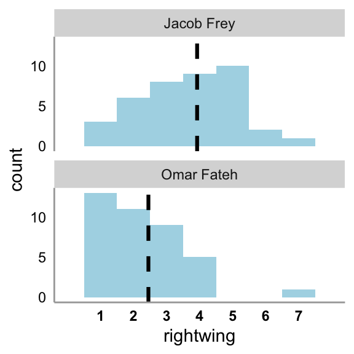

```r
means <- df_lebe_elg %>%
  filter(PLACENAME == "Minneapolis") %>%
  select(PID,CAND_1:CAND_2,cand1_rightwing,cand2_rightwing) %>%
  pivot_longer(-c(PID,cand1_rightwing,cand2_rightwing),
               names_to = "names",
               values_to = "candidate") %>%
  mutate(rightwing = ifelse(names == "CAND_1",cand1_rightwing,cand2_rightwing)) %>%
  select(PID,candidate,rightwing) %>%
  group_by(candidate) %>%
  summarise(score = mean(rightwing,na.rm = T)) %>%
  ungroup()

df_lebe_elg %>%
  filter(PLACENAME == "Minneapolis") %>%
  select(PID,CAND_1:CAND_2,cand1_rightwing,cand2_rightwing) %>%
  pivot_longer(-c(PID,cand1_rightwing,cand2_rightwing),
               names_to = "names",
               values_to = "candidate") %>%
  mutate(rightwing = ifelse(names == "CAND_1",cand1_rightwing,cand2_rightwing)) %>%
  select(PID,candidate,rightwing) %>%
  ggplot() +
  geom_histogram(aes(x = rightwing),
                 fill = "lightblue",
                 color = NA,
                 binwidth = 1) +
  scale_x_continuous(limits = c(0,8),
                     breaks = seq(1,7,1)) +
  geom_vline(data = means,mapping = aes(xintercept = score),
             color = "black",
             linetype = "dashed",
             size = 1.1) +
  theme(panel.grid.major = element_blank(),
        panel.grid.minor = element_blank(),
        panel.background = element_blank(),
        axis.ticks = element_blank(),
        axis.line = element_line(color = "grey66"),
        axis.text.y = element_text(color = "black"),
        axis.text.x = element_text(color = "black",
                                   face = "bold")) +
  facet_wrap(~candidate,nrow = 2)
```

# Analysis Plan

## Model 1

Random effects linear model: Continuous left behind measure as the predictor variable; voting intention for the political candidate who supports sweeping change as the outcome variable; election as random effect.

```r
m1 <- lmerTest::lmer(vote_sweep ~ lebe_cont_z + (1|PLACENAME),data = df_lebe_elg)

apa_lm <- apa_print(m1)

kbl(apa_lm$table) %>%
  kable_styling(bootstrap_options = "hover",
                full_width = F,
                position = "left")
```

| term | estimate | conf.int | statistic | df | p.value |
| --- | --- | --- | --- | --- | --- |
| Intercept | 0.52 | [0.25, 0.80] | 3.71 | 3.12 | .032 |
| Lebe cont z | -0.03 | [-0.07, 0.01] | -1.40 | 390.82 | .161 |

oh boy. that’s a bummer. That is *the opposite* of what we were hoping to find.

## Model 2

Random effects linear model: Continuous left behind measure as the predictor variable; voting intention for the political candidate who supports sweeping change as the outcome variable; election as random effect; party ID as control variable.

```r
m1 <- lmerTest::lmer(vote_sweep ~ lebe_cont_z + party_id + (1|PLACENAME),data = df_lebe_elg)

apa_lm <- apa_print(m1)

kbl(apa_lm$table) %>%
  kable_styling(bootstrap_options = "hover",
                full_width = F,
                position = "left")
```

| term | estimate | conf.int | statistic | df | p.value |
| --- | --- | --- | --- | --- | --- |
| Intercept | 0.46 | [0.17, 0.75] | 3.12 | 3.14 | .049 |
| Lebe cont z | 0.00 | [-0.04, 0.05] | 0.12 | 388.71 | .903 |
| Party idInd | 0.14 | [-0.01, 0.28] | 1.82 | 388.26 | .069 |
| Party idRep | 0.31 | [0.21, 0.42] | 5.71 | 388.41 | < .001 |

## Model 3

Random effects linear model: Continuous left behind measure as the predictor variable; voting intention for the political candidate who supports sweeping change as the outcome variable; election as random effect; party ID as control variable. (Filter out NJ)

```r
m1 <- lmerTest::lmer(vote_sweep ~ lebe_cont_z + party_id + (1|PLACENAME),data = df_lebe_elg %>% filter(PLACENAME != "New Jersey"))

apa_lm <- apa_print(m1)

kbl(apa_lm$table) %>%
  kable_styling(bootstrap_options = "hover",
                full_width = F,
                position = "left")
```

| term | estimate | conf.int | statistic | df | p.value |
| --- | --- | --- | --- | --- | --- |
| Intercept | 0.71 | [0.44, 0.99] | 5.08 | 2.04 | .035 |
| Lebe cont z | 0.01 | [-0.05, 0.06] | 0.23 | 177.65 | .816 |
| Party idInd | -0.04 | [-0.24, 0.16] | -0.36 | 177.05 | .721 |
| Party idRep | -0.68 | [-0.83, -0.53] | -9.00 | 177.04 | < .001 |

# Exploratory Analysis

## Break it down by election

The first thing we want to do is see how this effect varies by election.

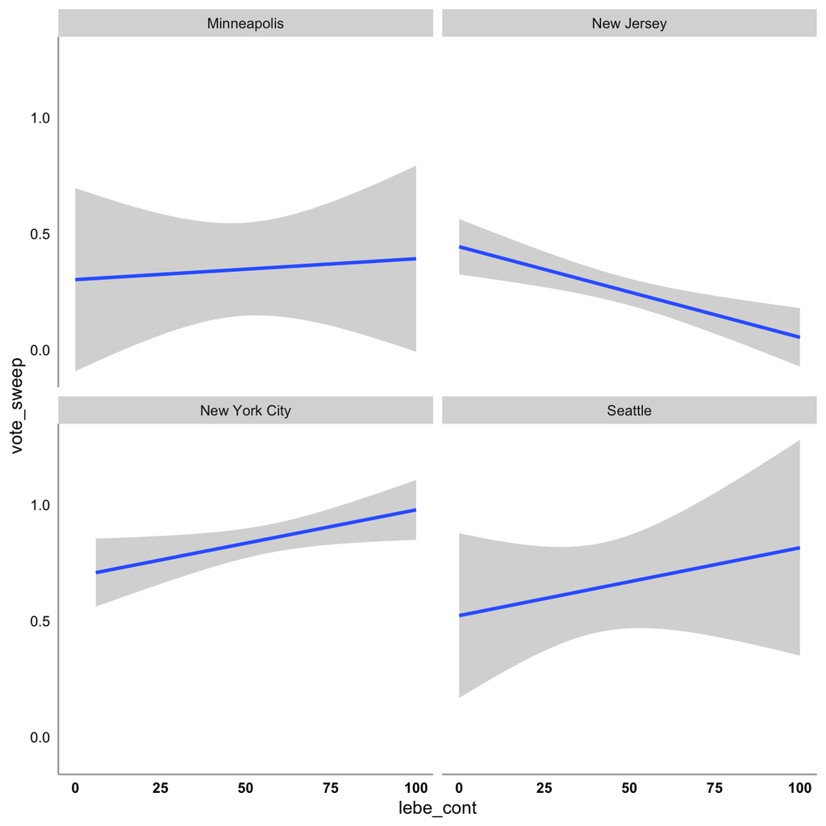

### New Jersey

```r
m1 <- lm(vote_sweep ~ lebe_cont_z,data = df_lebe_elg %>% filter(PLACENAME == "New Jersey"))

apa_lm <- apa_print(m1)

kbl(apa_lm$table) %>%
  kable_styling(bootstrap_options = "hover",
                full_width = F,
                position = "left")
```

| term | estimate | conf.int | statistic | df | p.value |
| --- | --- | --- | --- | --- | --- |
| Intercept | 0.25 | [0.19, 0.31] | 8.59 | 210 | < .001 |
| Lebe cont z | -0.11 | [-0.16, -0.05] | -3.54 | 210 | < .001 |

### New York City

```r
m1 <- lm(vote_sweep ~ lebe_cont_z,data = df_lebe_elg %>% filter(PLACENAME == "New York City"))

apa_lm <- apa_print(m1)

kbl(apa_lm$table) %>%
  kable_styling(bootstrap_options = "hover",
                full_width = F,
                position = "left")
```

| term | estimate | conf.int | statistic | df | p.value |
| --- | --- | --- | --- | --- | --- |
| Intercept | 0.83 | [0.77, 0.90] | 25.63 | 127 | < .001 |
| Lebe cont z | 0.08 | [0.01, 0.15] | 2.17 | 127 | .032 |

### Seattle

```r
m1 <- lm(vote_sweep ~ lebe_cont_z,data = df_lebe_elg %>% filter(PLACENAME == "Seattle"))

apa_lm <- apa_print(m1)

kbl(apa_lm$table) %>%
  kable_styling(bootstrap_options = "hover",
                full_width = F,
                position = "left")
```

| term | estimate | conf.int | statistic | df | p.value |
| --- | --- | --- | --- | --- | --- |
| Intercept | 0.67 | [0.47, 0.86] | 6.88 | 26 | < .001 |
| Lebe cont z | 0.08 | [-0.12, 0.27] | 0.83 | 26 | .414 |

### Minneapolis

```r
m1 <- lm(vote_sweep ~ lebe_cont_z,data = df_lebe_elg %>% filter(PLACENAME == "Minneapolis"))

apa_lm <- apa_print(m1)

kbl(apa_lm$table) %>%
  kable_styling(bootstrap_options = "hover",
                full_width = F,
                position = "left")
```

| term | estimate | conf.int | statistic | df | p.value |
| --- | --- | --- | --- | --- | --- |
| Intercept | 0.35 | [0.15, 0.55] | 3.57 | 24 | .002 |
| Lebe cont z | 0.02 | [-0.16, 0.21] | 0.27 | 24 | .789 |

Ok. That gives us a bit of a clue into what’s going on. The effect might depend on the direction of the candidate (NJ’s sweeping change candidate is Republican)… Let’s see.

## Moderator: Perceived direction

```r
cands_sweep = c("Zohran Mamdani","Jack Ciattarelli","Katie Wilson","Omar Fateh")
cands_inc = c("Andrew Cuomo","Mikie Sherill","Bruce Harrell","Jacob Frey")

df_lebe_elg <- df_lebe_elg %>%
  mutate(seen_rightwing = case_when(CAND_1 %in% cands_sweep ~ cand1_rightwing,
                                CAND_2 %in% cands_sweep ~ cand2_rightwing))

m1 <- lmerTest::lmer(vote_sweep ~ lebe_cont_z*seen_rightwing + (1|PLACENAME),data = df_lebe_elg)

apa_lm <- apa_print(m1)

kbl(apa_lm$table) %>%
  kable_styling(bootstrap_options = "hover",
                full_width = F,
                position = "left")
```

| term | estimate | conf.int | statistic | df | p.value |
| --- | --- | --- | --- | --- | --- |
| Intercept | 0.68 | [0.43, 0.93] | 5.34 | 4.79 | .004 |
| Lebe cont z | 0.10 | [0.01, 0.19] | 2.15 | 389.96 | .033 |
| Seen rightwing | -0.05 | [-0.08, -0.01] | -2.55 | 248.53 | .011 |
| Lebe cont z $\times$ Seen rightwing | -0.03 | [-0.05, -0.01] | -3.18 | 389.33 | .002 |

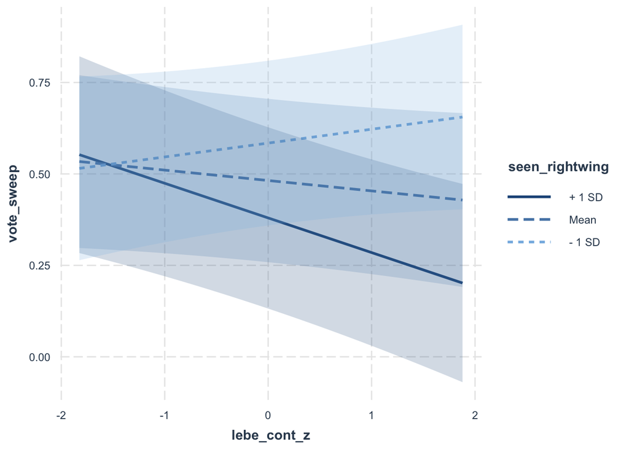

```r
interact_plot(m1,
              pred = "lebe_cont_z",
              modx = "seen_rightwing",
              interval = T)
```

This is very informative, actually. And it goes against the Cooley findings. Ok.

Basically, when the sweeping change candidate is seen as **left-wing**, we’re seeing a **positive relationship** between being left behind and voting for that candidate. When the sweeping change candidate is seen as **right-wing**, we’re seeing a **negative relationship** between being left behind and voting for that candidate.

## Moderator: Perceived change

Maybe the individual’s perception of the candidates matters (as opposed to our pre-tested categorizations)

```r
cands_sweep = c("Zohran Mamdani","Jack Ciattarelli","Katie Wilson","Omar Fateh")
cands_inc = c("Andrew Cuomo","Mikie Sherill","Bruce Harrell","Jacob Frey")

df_lebe_elg <- df_lebe_elg %>%
  mutate(seen_change = case_when(CAND_1 %in% cands_sweep ~ cand1_change,
                                CAND_2 %in% cands_sweep ~ cand2_change))

m1 <- lmerTest::lmer(vote_sweep ~ lebe_cont_z*seen_change + (1|PLACENAME),data = df_lebe_elg)

apa_lm <- apa_print(m1)

kbl(apa_lm$table) %>%
  kable_styling(bootstrap_options = "hover",
                full_width = F,
                position = "left")
```

| term | estimate | conf.int | statistic | df | p.value |
| --- | --- | --- | --- | --- | --- |
| Intercept | 0.62 | [0.32, 0.93] | 3.99 | 4.46 | .013 |
| Lebe cont z | -0.12 | [-0.24, 0.01] | -1.85 | 388.19 | .065 |
| Seen change | -0.02 | [-0.05, 0.01] | -1.57 | 388.78 | .117 |
| Lebe cont z $\times$ Seen change | 0.02 | [-0.01, 0.04] | 1.45 | 388.15 | .147 |

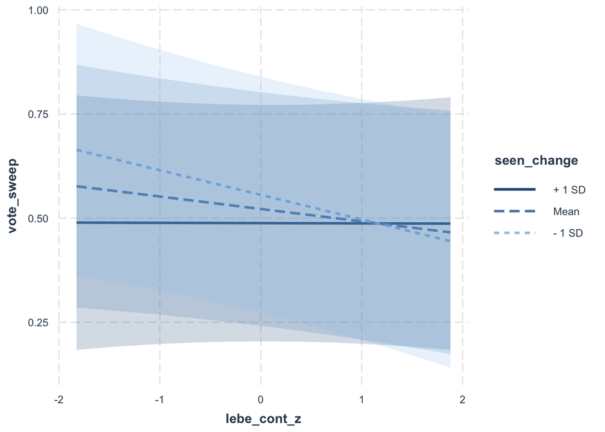

```r
interact_plot(m1,
              pred = "lebe_cont_z",
              modx = "seen_change",
              interval = T)
```

Hmm, not much going on.

## Moderator: Participants’ ideology

```r
m1 <- lmerTest::lmer(vote_sweep ~ lebe_cont_z*ideo_z + (1|PLACENAME),data = df_lebe_elg %>% filter(PLACENAME %in% c("New Jersey","New York City")))

apa_lm <- apa_print(m1)

kbl(apa_lm$table) %>%
  kable_styling(bootstrap_options = "hover",
                full_width = F,
                position = "left")
```

| term | estimate | conf.int | statistic | df | p.value |
| --- | --- | --- | --- | --- | --- |
| Intercept | 0.55 | [-0.09, 1.19] | 1.69 | 1.00 | .340 |
| Lebe cont z | -0.01 | [-0.06, 0.04] | -0.39 | 336.03 | .695 |
| Ideo z | 0.12 | [0.08, 0.17] | 5.42 | 336.06 | < .001 |
| Lebe cont z $\times$ Ideo z | -0.05 | [-0.09, -0.01] | -2.47 | 336.00 | .014 |

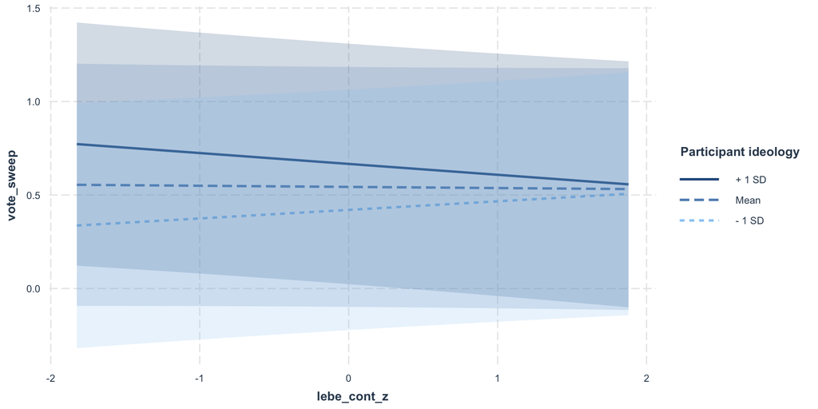

```r
interact_plot(
  m1,
  pred = lebe_cont_z,
  modx = ideo_z,
  plot.points = FALSE,
  interval = TRUE,
  legend.main = "Participant ideology"
)
```

### New Jersey

```r
m1 <- lm(vote_sweep ~ lebe_cont_z*ideo_z,data = df_lebe_elg %>% filter(PLACENAME == "New Jersey"))

apa_lm <- apa_print(m1)

kbl(apa_lm$table) %>%
  kable_styling(bootstrap_options = "hover",
                full_width = F,
                position = "left")
```

| term | estimate | conf.int | statistic | df | p.value |
| --- | --- | --- | --- | --- | --- |
| Intercept | 0.22 | [0.18, 0.27] | 10.05 | 208 | < .001 |
| Lebe cont z | 0.01 | [-0.04, 0.05] | 0.32 | 208 | .752 |
| Ideo z | 0.30 | [0.26, 0.35] | 13.59 | 208 | < .001 |
| Lebe cont z $\times$ Ideo z | -0.02 | [-0.06, 0.02] | -0.84 | 208 | .404 |

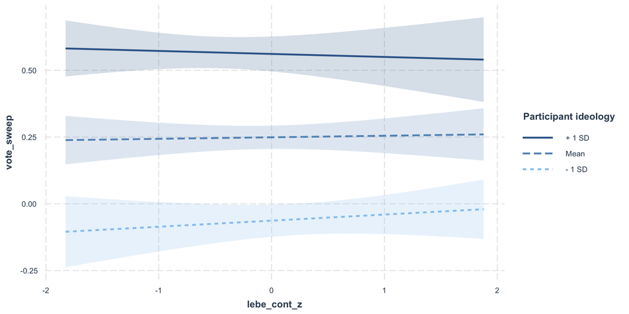

```r
interact_plot(
  m1,
  pred = lebe_cont_z,
  modx = ideo_z,
  plot.points = FALSE,
  interval = TRUE,
  legend.main = "Participant ideology"
)
```

### New York City

```r
m1 <- lm(vote_sweep ~ lebe_cont_z*ideo_z,data = df_lebe_elg %>% filter(PLACENAME == "New York City"))

apa_lm <- apa_print(m1)

kbl(apa_lm$table) %>%
  kable_styling(bootstrap_options = "hover",
                full_width = F,
                position = "left")
```

| term | estimate | conf.int | statistic | df | p.value |
| --- | --- | --- | --- | --- | --- |
| Intercept | 0.79 | [0.73, 0.84] | 28.25 | 125 | < .001 |
| Lebe cont z | 0.02 | [-0.04, 0.09] | 0.76 | 125 | .446 |
| Ideo z | -0.23 | [-0.29, -0.18] | -8.06 | 125 | < .001 |
| Lebe cont z $\times$ Ideo z | 0.03 | [-0.03, 0.10] | 1.07 | 125 | .289 |

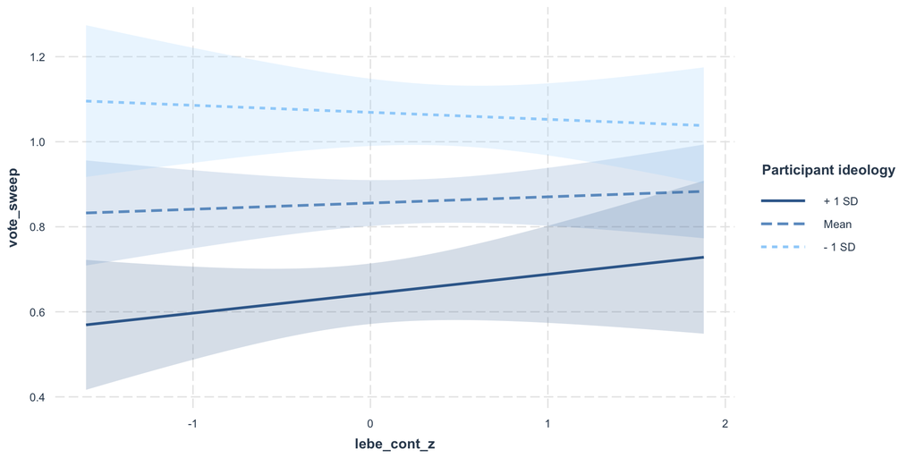

```r
interact_plot(
  m1,
  pred = lebe_cont_z,
  modx = ideo_z,
  plot.points = FALSE,
  interval = TRUE,
  legend.main = "Participant ideology"
)
```

# Analysis: T2 measure

## Model 1

Random effects linear model: Continuous left behind measure as the predictor variable; voting behavior for the political candidate who supports sweeping change as the outcome variable; election as random effect.

```r
m1 <- lmerTest::lmer(vote_sweep_t2 ~ lebe_cont_z + (1|PLACENAME),data = df_lebe_elg)

apa_lm <- apa_print(m1)

kbl(apa_lm$table) %>%
  kable_styling(bootstrap_options = "hover",
                full_width = F,
                position = "left")
```

| term | estimate | conf.int | statistic | df | p.value |
| --- | --- | --- | --- | --- | --- |
| Intercept | 0.53 | [0.28, 0.78] | 4.10 | 3.28 | .022 |
| Lebe cont z | -0.01 | [-0.05, 0.04] | -0.24 | 300.17 | .811 |

## Model 2

Random effects linear model: Continuous left behind measure as the predictor variable; voting intention for the political candidate who supports sweeping change as the outcome variable; election as random effect; party ID as control variable.

```r
m1 <- lmerTest::lmer(vote_sweep_t2 ~ lebe_cont_z + party_id + (1|PLACENAME),data = df_lebe_elg)

apa_lm <- apa_print(m1)

kbl(apa_lm$table) %>%
  kable_styling(bootstrap_options = "hover",
                full_width = F,
                position = "left")
```

| term | estimate | conf.int | statistic | df | p.value |
| --- | --- | --- | --- | --- | --- |
| Intercept | 0.47 | [0.20, 0.74] | 3.44 | 3.30 | .036 |
| Lebe cont z | 0.02 | [-0.03, 0.07] | 0.90 | 298.03 | .367 |
| Party idInd | 0.07 | [-0.08, 0.22] | 0.87 | 297.51 | .387 |
| Party idRep | 0.32 | [0.19, 0.44] | 5.03 | 297.56 | < .001 |

## Model 3

Random effects linear model: Continuous left behind measure as the predictor variable; voting intention for the political candidate who supports sweeping change as the outcome variable; election as random effect; party ID as control variable. (Filter out NJ)

```r
m1 <- lmerTest::lmer(vote_sweep_t2 ~ lebe_cont_z + party_id + (1|PLACENAME),data = df_lebe_elg %>% filter(PLACENAME != "New Jersey"))

apa_lm <- apa_print(m1)

kbl(apa_lm$table) %>%
  kable_styling(bootstrap_options = "hover",
                full_width = F,
                position = "left")
```

| term | estimate | conf.int | statistic | df | p.value |
| --- | --- | --- | --- | --- | --- |
| Intercept | 0.75 | [0.56, 0.94] | 7.63 | 2.25 | .012 |
| Lebe cont z | 0.03 | [-0.02, 0.09] | 1.14 | 133.37 | .256 |
| Party idInd | -0.04 | [-0.26, 0.18] | -0.39 | 132.26 | .700 |
| Party idRep | -0.70 | [-0.87, -0.53] | -8.15 | 132.33 | < .001 |

# T2 Measure: Break it down by election

## New Jersey

```r
m1 <- lm(vote_sweep_t2 ~ lebe_cont_z,data = df_lebe_elg %>% filter(PLACENAME == "New Jersey"))

apa_lm <- apa_print(m1)

kbl(apa_lm$table) %>%
  kable_styling(bootstrap_options = "hover",
                full_width = F,
                position = "left")
```

| term | estimate | conf.int | statistic | df | p.value |
| --- | --- | --- | --- | --- | --- |
| Intercept | 0.23 | [0.17, 0.30] | 7.09 | 164 | < .001 |
| Lebe cont z | -0.08 | [-0.14, -0.01] | -2.28 | 164 | .024 |

## New York City

```r
m1 <- lm(vote_sweep_t2 ~ lebe_cont_z,data = df_lebe_elg %>% filter(PLACENAME == "New York City"))

apa_lm <- apa_print(m1)

kbl(apa_lm$table) %>%
  kable_styling(bootstrap_options = "hover",
                full_width = F,
                position = "left")
```

| term | estimate | conf.int | statistic | df | p.value |
| --- | --- | --- | --- | --- | --- |
| Intercept | 0.81 | [0.74, 0.89] | 21.58 | 94 | < .001 |
| Lebe cont z | 0.11 | [0.03, 0.18] | 2.72 | 94 | .008 |

## Seattle

```r
m1 <- lm(vote_sweep_t2 ~ lebe_cont_z,data = df_lebe_elg %>% filter(PLACENAME == "Seattle"))

apa_lm <- apa_print(m1)

kbl(apa_lm$table) %>%
  kable_styling(bootstrap_options = "hover",
                full_width = F,
                position = "left")
```

| term | estimate | conf.int | statistic | df | p.value |
| --- | --- | --- | --- | --- | --- |
| Intercept | 0.57 | [0.31, 0.82] | 4.69 | 19 | < .001 |
| Lebe cont z | -0.01 | [-0.22, 0.21] | -0.07 | 19 | .941 |

## Minneapolis

```r
m1 <- lm(vote_sweep_t2 ~ lebe_cont_z,data = df_lebe_elg %>% filter(PLACENAME == "Minneapolis"))

apa_lm <- apa_print(m1)

kbl(apa_lm$table) %>%
  kable_styling(bootstrap_options = "hover",
                full_width = F,
                position = "left")
```

| term | estimate | conf.int | statistic | df | p.value |
| --- | --- | --- | --- | --- | --- |
| Intercept | 0.47 | [0.23, 0.71] | 4.13 | 19 | < .001 |
| Lebe cont z | 0.05 | [-0.17, 0.27] | 0.48 | 19 | .636 |

# T2 outcome - Moderated by Perceived direction

```r
cands_sweep = c("Zohran Mamdani","Jack Ciattarelli","Katie Wilson","Omar Fateh")
cands_inc = c("Andrew Cuomo","Mikie Sherill","Bruce Harrell","Jacob Frey")

df_lebe_elg <- df_lebe_elg %>%
  mutate(seen_rightwing = case_when(CAND_1 %in% cands_sweep ~ cand1_rightwing,
                                CAND_2 %in% cands_sweep ~ cand2_rightwing))

m1 <- lmerTest::lmer(vote_sweep_t2 ~ lebe_cont_z*seen_rightwing + (1|PLACENAME),data = df_lebe_elg)

apa_lm <- apa_print(m1)

kbl(apa_lm$table) %>%
  kable_styling(bootstrap_options = "hover",
                full_width = F,
                position = "left")
```

| term | estimate | conf.int | statistic | df | p.value |
| --- | --- | --- | --- | --- | --- |
| Intercept | 0.65 | [0.40, 0.89] | 5.13 | 5.65 | .003 |
| Lebe cont z | 0.11 | [0.01, 0.21] | 2.08 | 299.11 | .038 |
| Seen rightwing | -0.04 | [-0.08, 0.01] | -1.68 | 138.02 | .096 |
| Lebe cont z $\times$ Seen rightwing | -0.03 | [-0.05, -0.01] | -2.47 | 298.32 | .014 |

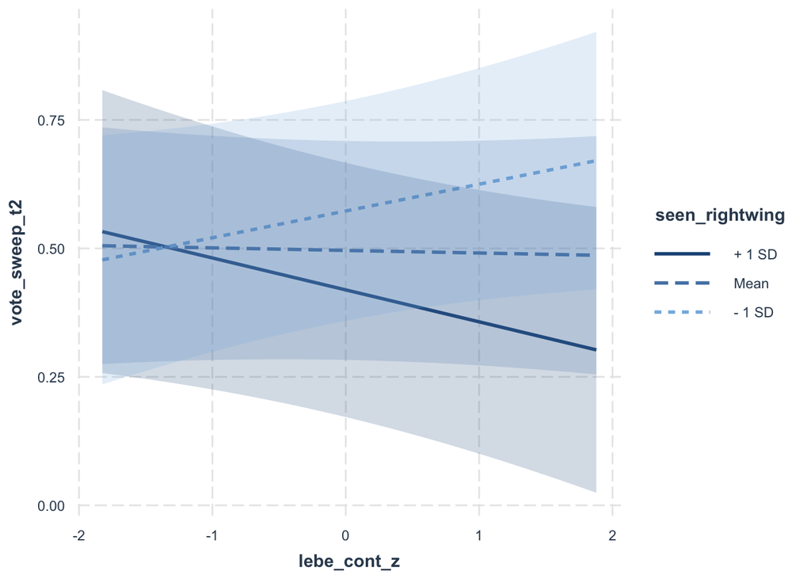

```r
interact_plot(m1,
              pred = "lebe_cont_z",
              modx = "seen_rightwing",
              interval = T)
```